# Mental Health Effect on Heart Disease

Group_3 Dustin Riles, Nina Ebensperger, Laya Ponswarnalaya

2022-12-14

# 1 Mental Health and Heart Disease

[figure not shown]

The question becomes:

How does the quality of someone’s mental health impact their probability of heart disease and impact other contributing factors to having heart disease?

## 1.1 About the Dataset

The dataset is originally from the CDC’s Behavioral Risk Factor Surveillance System (BRFSS). Which conducts an annual telephone survey on the current health status of U.S. residents. The BRFSS collects the responses from over 400,000 adults living in the U.S. a year. This particular dataset is from 2020 and contains 401,958 rows and 279 columns.

The survey consisted of questions regarding the status of the survey takers health. The questions were largely an input of yes or no. Please see breakdown of question and Variable below:

Physical Health: ‘For how many days during the past 30 days was your physical health not good?’.

Mental health: Thinking about your mental health, for how many days during the past 30 days was your mental health not good?

Difficulty Walking: Do you have serious difficulty walking or climbing stairs?

Kidney disease: Not including kidney stones, bladder infection or incontinence, were you ever told you had kidney disease?

Smoking: have you smoked at least 100 cigarettes in your entire life?

The respondent would then reply with a yes or no. Other questions gave the survey takers the option to input their response. Please see breakdown of question and Variable below:

BMI: manual input numeric

Race: imputed value

Sleep time: On average, how many hours of sleep do you get in a 24-hour period? Numeric

Physical Activity: Adults who reported doing physical activity or exercise during the past 30 days other than their regular job

Mental health: Thinking about your mental health, for how many days during the past 30 days was your mental health not good?

Physical health : For how many days during the past 30 days was your physical health not good?

Lastly, variables were also in certain ranks. This was the case for the variable Age.

Our dataset, while originally from the CDC, was taken from Kaggle where it was edited to having 18 variables deemed most relevant to heart health.

# 2 Why this Dataset?

The Personal Key indicators of Heart Disease dataset was chosen for various reasons.

One being that the data had already been brought down to the 18 most relevant variables. From there we were able to pick out variables for our model.

The main factor to choosing this dataset was the wide range of methods we could use to make models. There was amble categorical values, factor values, and numeric values to use to create a model.

Categorical Values Include

- Heart Disease
- Smoking
- Alcohol Drinking
- Stroke
- Difficultly Walking
- Sex
- Diabetic
- Asthma
- Kidney Disease
- Skin Cancer
- Race

Factor/Rank Values Include

- Age
- General Health

Numeric Values

# 3 EDA

We did some exploratory data analysis to get an idea of what our variables look like.

```r
# Replace No for Heart Disease with 0
df$HeartDisease[df$HeartDisease == "No"] <- 0
# Replace Yes for Heart Disease with 1
df$HeartDisease[df$HeartDisease == "Yes"] <- 1
# Convert Heart Disease to factor variable
df$HeartDisease <- as.factor(df$HeartDisease)
table(df$HeartDisease)

# Replace No for Smoking with 0
df$Smoking[df$Smoking == "No"] <- 0
# Replace Yes for Smoking with 1
df$Smoking[df$Smoking == "Yes"] <- 1
# Convert Smoking to factor variable
df$Smoking <- as.factor(df$Smoking)
table(df$Smoking)

# Replace No for Alcohol Drinking with 0
df$AlcoholDrinking[df$AlcoholDrinking == "No"] <- 0
# Replace Yes for Alcohol Drinking with 1
df$AlcoholDrinking[df$AlcoholDrinking == "Yes"] <- 1
# Convert Alcohol Drinking to factor variable
df$AlcoholDrinking <- as.factor(df$AlcoholDrinking)
table(df$AlcoholDrinking)

# Replace No for Stroke with 0
df$Stroke[df$Stroke == "No"] <- 0
# Replace Yes for Stroke with 1
df$Stroke[df$Stroke == "Yes"] <- 1
# Convert Stroke to factor variable
df$Stroke <- as.factor(df$Stroke)
table(df$Stroke)

# Replace No for DiffWalking with 0
df$DiffWalking[df$DiffWalking == "No"] <- 0
# Replace Yes for DiffWalking with 1
df$DiffWalking[df$DiffWalking == "Yes"] <- 1
# Convert DiffWalking to factor variable
df$DiffWalking <- as.factor(df$DiffWalking)
table(df$DiffWalking)

# Replace Male for Sex with 0
df$Sex[df$Sex == "Male"] <- 0
# Replace Female for Sex with 1
df$Sex[df$Sex == "Female"] <- 1
# Convert Sex to factor variable
df$Sex <- as.factor(df$Sex)
table(df$Sex)

# Replace No for Physical Activity with 0
df$PhysicalActivity[df$PhysicalActivity == "No"] <- 0
# Replace Yes for Physical Activity with 1
df$PhysicalActivity[df$PhysicalActivity == "Yes"] <- 1
# Convert Physical Activity to factor variable
df$PhysicalActivity <- as.factor(df$PhysicalActivity)
table(df$PhysicalActivity)

# Replace No for Asthma with 0
df$Asthma[df$Asthma == "No"] <- 0
# Replace Yes for Asthma with 1
df$Asthma[df$Asthma == "Yes"] <- 1
# Convert Asthma to factor variable
df$Asthma <- as.factor(df$Asthma)
table(df$Asthma)

# Replace No for Kidney Disease with 0
df$KidneyDisease[df$KidneyDisease == "No"] <- 0
# Replace Yes for Kidney Disease with 1
df$KidneyDisease[df$KidneyDisease == "Yes"] <- 1
# Convert Kidney Disease to factor variable
df$KidneyDisease <- as.factor(df$KidneyDisease)
table(df$KidneyDisease)

# Replace No for Skin Cancer with 0
df$SkinCancer[df$SkinCancer == "No"] <- 0
# Repalce Yes for Skin Cancer with 1
df$SkinCancer[df$SkinCancer == "Yes"] <- 1
# Convert Skin Cancer to factor variable
df$SkinCancer <- as.factor(df$SkinCancer)
table(df$SkinCancer)

# Replace Poor for GenHealth with 0
df$GenHealth[df$GenHealth == "Poor"] <- 0
# Replace Fair for GenHealth with 1
df$GenHealth[df$GenHealth == "Fair"] <- 1
# Replace Good for GenHealth with 2
df$GenHealth[df$GenHealth == "Good"] <- 2
# Replace Very Good for GenHealth with 3
df$GenHealth[df$GenHealth == "Very good"] <- 3
# Replace Excellent for GenHealth with 4
df$GenHealth[df$GenHealth == "Excellent"] <- 4
# Convert GenHealth to factor variable
df$GenHealth <- as.factor(df$GenHealth)
table(df$GenHealth)

# Replace No for Diabetic with 0
df$Diabetic[df$Diabetic == "No"] <- 0
# Replace Yes for Diabetic with 1
df$Diabetic[df$Diabetic == "Yes"] <- 1
# Replace "No, borderline diabetes" with 2
df$Diabetic[df$Diabetic == "No, borderline diabetes"] <- 2
# Replace "Yes (during pregnancy) with 3
df$Diabetic[df$Diabetic == "Yes (during pregnancy)"] <- 3
# Convert Diabetic to factor variable
df$Diabetic <- as.factor(df$Diabetic)
table(df$Diabetic)

# Replace White for Race with 0
df$Race[df$Race == "White"] <- 0
# Replace Black for Race with 1
df$Race[df$Race == "Black"] <- 1
# Replace Hispanic for Race with 2
df$Race[df$Race == "Hispanic"] <- 2
# Replace Asian for Race with 3
df$Race[df$Race == "Asian"] <- 3
# Replace American Indian/Alaskan Native for Race with 4
df$Race[df$Race == "American Indian/Alaskan Native"] <- 4
# Replace Other for Race with 5
df$Race[df$Race == "Other"] <- 5
df$Race <- as.factor(df$Race)
table(df$Race)

df$AgeCategory[df$AgeCategory == "18-24"] <- 0
df$AgeCategory[df$AgeCategory == "25-29"] <- 1
df$AgeCategory[df$AgeCategory == "30-34"] <- 2
df$AgeCategory[df$AgeCategory == "35-39"] <- 3
df$AgeCategory[df$AgeCategory == "40-44"] <- 4
df$AgeCategory[df$AgeCategory == "45-49"] <- 5
df$AgeCategory[df$AgeCategory == "50-54"] <- 6
df$AgeCategory[df$AgeCategory == "55-59"] <- 7
df$AgeCategory[df$AgeCategory == "60-64"] <- 8
df$AgeCategory[df$AgeCategory == "65-69"] <- 9
df$AgeCategory[df$AgeCategory == "70-74"] <- 10
df$AgeCategory[df$AgeCategory == "75-79"] <- 11
df$AgeCategory[df$AgeCategory == "80 or older"] <- 12
df$AgeCategory <- as.factor(df$AgeCategory)
table(df$AgeCategory)
```

[output not shown]

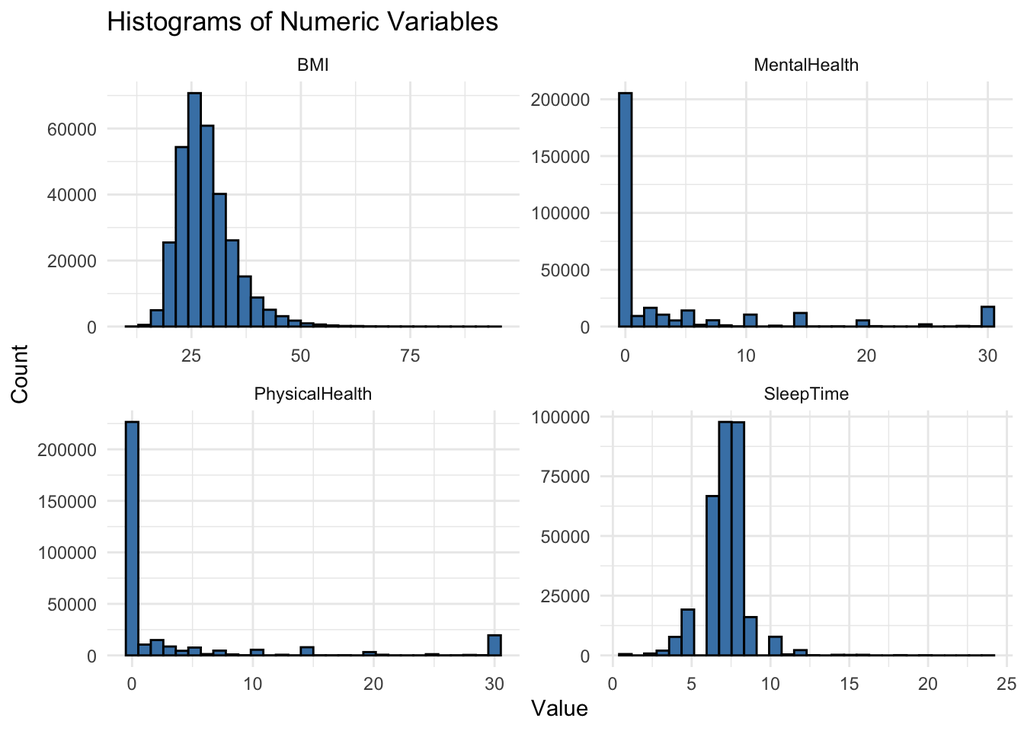

```r
# EDA


df %>%
  dplyr::select(MentalHealth, PhysicalHealth, BMI, SleepTime) %>%
  gather(variable, value) %>%
  ggplot(aes(x = value)) +
  geom_histogram(fill = "steelblue", color = "black") +
  facet_wrap(~ variable, scales = "free") + # Free scales so the graphs are readable
  labs(title = "Histograms of Numeric Variables", x = "Value", y = "Count") +
  theme_minimal()
```

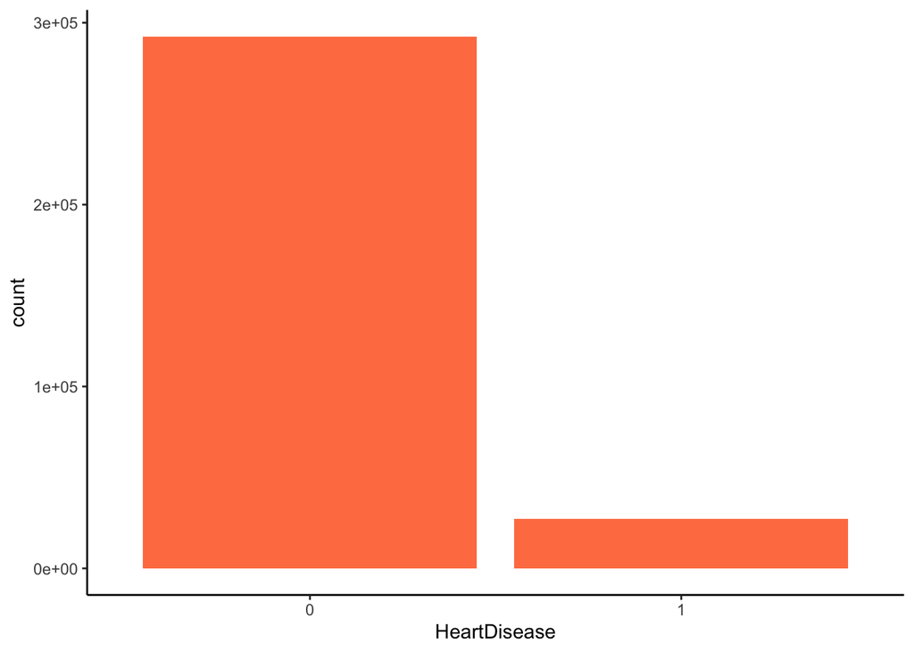

```r
  #bar plot count dependent variable (heart disease)
ggplot(df, aes(x = HeartDisease)) +
  geom_bar(fill = "coral") +
    theme_classic()
```

```r
df1 = subset(df, select = c("BMI", "PhysicalHealth", "MentalHealth", "SleepTime"))

dfcor = cor(df1)

dfcor
```

```
##                    BMI PhysicalHealth MentalHealth SleepTime
## BMI             1.0000         0.1098       0.0641   -0.0518
## PhysicalHealth  0.1098         1.0000       0.2880   -0.0614
## MentalHealth    0.0641         0.2880       1.0000   -0.1197
## SleepTime      -0.0518        -0.0614      -0.1197    1.0000
```

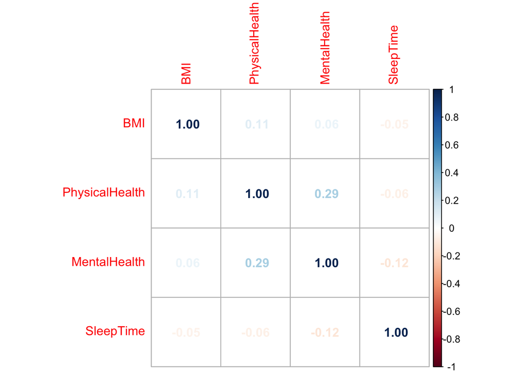

```r
loadPkg("corrplot")

corrplot(dfcor, method = 'number')
```

```r
table(df$HeartDisease)
```

```
##
##      0      1
## 292422  27373
```

```r
model1 <- glm(HeartDisease~MentalHealth + BMI + GenHealth + AgeCategory + Sex + PhysicalHealth + SleepTime, data = df, family = "binomial")
model2 <- glm(HeartDisease~AlcoholDrinking + BMI + PhysicalHealth + GenHealth + AgeCategory + SleepTime + Sex, data = df, family = "binomial")

models <- list (model1, model2)
model.names <- c('model1', 'model2')

summary(model1)
```

```
##
## Call:
## glm(formula = HeartDisease ~ MentalHealth + BMI + GenHealth +
##     AgeCategory + Sex + PhysicalHealth + SleepTime, family = "binomial",
##     data = df)
##
## Deviance Residuals:
##    Min      1Q  Median      3Q     Max
## -1.809  -0.434  -0.258  -0.129   3.632
##
## Coefficients:
##                 Estimate Std. Error z value Pr(>|z|)
## (Intercept)    -3.584948   0.102470  -34.99  < 2e-16 ***
## MentalHealth    0.007556   0.000857    8.82  < 2e-16 ***
## BMI             0.017373   0.001064   16.33  < 2e-16 ***
## GenHealth1     -0.530530   0.027412  -19.35  < 2e-16 ***
## GenHealth2     -1.175185   0.029158  -40.30  < 2e-16 ***
## GenHealth3     -1.874039   0.031403  -59.68  < 2e-16 ***
## GenHealth4     -2.421892   0.038957  -62.17  < 2e-16 ***
## AgeCategory1    0.173134   0.124155    1.39     0.16
## AgeCategory10   3.164035   0.089921   35.19  < 2e-16 ***
## AgeCategory11   3.410247   0.090336   37.75  < 2e-16 ***
## AgeCategory12   3.652404   0.090017   40.57  < 2e-16 ***
## AgeCategory2    0.569191   0.111003    5.13  2.9e-07 ***
## AgeCategory3    0.723322   0.106171    6.81  9.6e-12 ***
## AgeCategory4    1.161403   0.099788   11.64  < 2e-16 ***
## AgeCategory5    1.516168   0.096169   15.77  < 2e-16 ***
## AgeCategory6    1.957453   0.092817   21.09  < 2e-16 ***
## AgeCategory7    2.254435   0.091285   24.70  < 2e-16 ***
## AgeCategory8    2.552931   0.090406   28.24  < 2e-16 ***
## AgeCategory9    2.828659   0.090082   31.40  < 2e-16 ***
## Sex1           -0.733436   0.013964  -52.52  < 2e-16 ***
## PhysicalHealth  0.008087   0.000819    9.88  < 2e-16 ***
## SleepTime      -0.022350   0.004279   -5.22  1.8e-07 ***
## ---
## Signif. codes:  0 '***' 0.001 '**' 0.01 '*' 0.05 '.' 0.1 ' ' 1
##
## (Dispersion parameter for binomial family taken to be 1)
##
##     Null deviance: 186906  on 319794  degrees of freedom
## Residual deviance: 150305  on 319773  degrees of freedom
## AIC: 150349
##
## Number of Fisher Scoring iterations: 7
```

```r
aictab(cand.set = models, modnames = model.names)
```

```
##
## Model selection based on AICc:
##
##         K   AICc Delta_AICc AICcWt Cum.Wt     LL
## model1 22 150349        0.0      1      1 -75152
## model2 22 150376       27.4      0      1 -75166
```

# 4 Model Selection

Using the AICc, we tested which model would be best to select. When replacing mental health wit alcohol drinking from the model we can see that the AIC increases. So we can see that the better model to use includes mental health. Furthermore, model1 is the better model as it carries 100% of the cumulative model weight.

Nevertheless the AIC is relatively high at 150349.

```r
#Testing the model

loadPkg("regclass")
# confusion_matrix(model1)
xkabledply( confusion_matrix(model1), title = "Confusion matrix from Logit Model" )
```

Confusion matrix from Logit Model

|  | Predicted 0 | Predicted 1 | Total |
| --- | --- | --- | --- |
| Actual 0 | 291066 | 1356 | 292422 |
| Actual 1 | 26072 | 1301 | 27373 |
| Total | 317138 | 2657 | 319795 |

```r
unloadPkg("regclass")
```

# 5 Confusion Matrix

As we can see in the confusion matrix, the logit model, model1, does not affect the target variable (heart disease) significantly. In the confusion matrix, we can calculate that the accuracy of this model is high at 91.5%. The misclassification rate is at 8.6%, meaning that the model is wrong 8.6%. However the recall is at 4.8%, which means of the cases that were positive only 4.8% were classified correctly. Additionally the precision of the model is at 48.97%. This means that when the case is yes, the model accurately predicts yes 48.97% of the time.

With that analysis, we decided to move our Logit model to a random forest.

```r
set.seed(2904)
s<-sort(sample(nrow(df),nrow(df)*.8))
train<-df[s,]
test<-df[-s,]
rm(s)

rf2<-randomForest(HeartDisease~MentalHealth + BMI + GenHealth + AgeCategory + Sex + PhysicalHealth + SleepTime,ntree=200,data=train)
rf2
```

```
##
## Call:
##  randomForest(formula = HeartDisease ~ MentalHealth + BMI + GenHealth +      AgeCategory + Sex + PhysicalHealth + SleepTime, data = train,      ntree = 200)
##                Type of random forest: classification
##                      Number of trees: 200
## No. of variables tried at each split: 2
##
##         OOB estimate of  error rate: 8.58%
## Confusion matrix:
##        0   1 class.error
## 0 233453 421      0.0018
## 1  21540 422      0.9808
```

```r
set.seed(2904)
rf<-randomForest(HeartDisease~.,ntree=200,data=train)
rf
```

```
##
## Call:
##  randomForest(formula = HeartDisease ~ ., data = train, ntree = 200)
##                Type of random forest: classification
##                      Number of trees: 200
## No. of variables tried at each split: 4
##
##         OOB estimate of  error rate: 8.53%
## Confusion matrix:
##        0    1 class.error
## 0 232072 1802     0.00771
## 1  20028 1934     0.91194
```

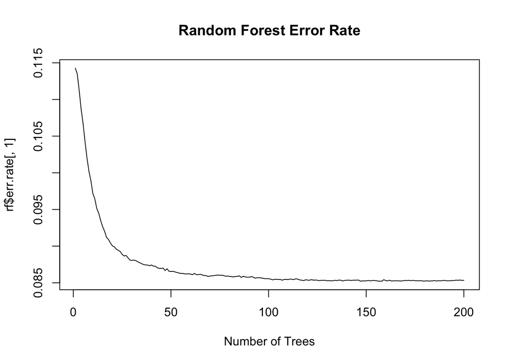

```r
plot(rf$err.rate[,1],type="l",main="Random Forest Error Rate",xlab="Number of Trees")
```

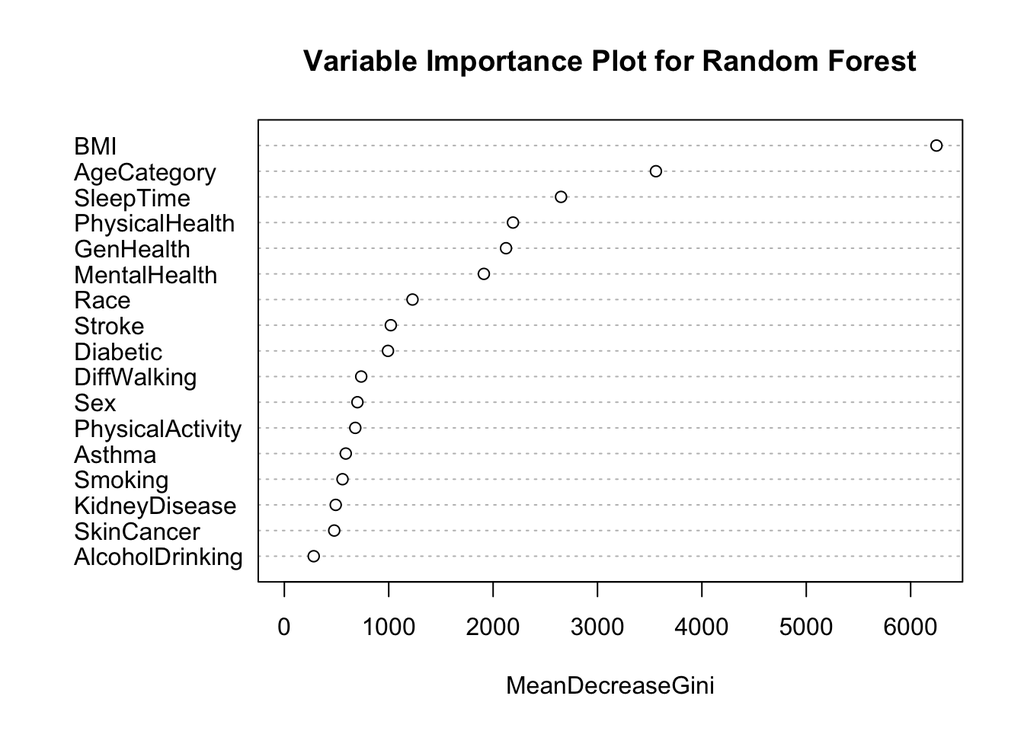

```r
varImpPlot(rf,main="Variable Importance Plot for Random Forest")
```

```r
rfpred<-predict(rf,test,type="class")
rft<-table(test$HeartDisease,rfpred)
rft
```

```
##    rfpred
##         0     1
##   0 58093   455
##   1  4960   451
```

# 6 Random Forests and Results

Since our data is highly unbalanced, we decided a random forest would be best to use as it is more powerful in its accuracy than a standard decision tree.

I choose to make a random forest that contains 200 trees, and while each tree may be over-fitted on its own. The final result considering all the trees together, will be as prone to the over fitting. The first step I did was split the dataset into train and test where 80% of the data will be used for training and the other 20% will be used for testing.

We can see that we used every 4 variables at every split, coming from the square-root of 18. Which increases the randomness of our algorithm.

# 7 Limitations

While our model has a high accuracy rate in predicting heart disease, there were a few limitations.

- Our data was heavily classified towards the no class in terms of heart disease.
- Mental Health observations were low. Mental Health awareness is still new to the public. People may not realize what having a bad mental health day means or looks like.
- People who already tested for Heart Disease by the time of the survey may already be taking steps to improve their health. So variables like physical health and mental health may not be enough to predict heart disease.
- The size of our dataset means more chances for outliers or incorrectly recorded observations. For example, someone who inputs their BMI might incorrectly imput their weight.

# 8 Future work

- In the future we would like to use other prediction models to see if an individual at a certain time could be at risk of hart disease regardless of their mental health.

# 9 References

CDC. (2022, September 6). Leading Causes of Death. National Center for Health Statistics. https://www.cdc.gov/nchs/fastats/leading-causes-of-death.htm

Heart Disease and Mental Health Disorders. (2020, May 6). CDC. https://www.cdc.gov/heartdisease/mentalhealth.htm

#Conslusion

## 9.1 Data dictionary

[output not shown]